# Homework 2021-22: Regression and PCA

# Combine response transformation and higer order modelling

Use `poly()` to perform linear modelling with respect to powers of the original predictors (up to degree `3`).

```r
polynomial_model <- lm(Y ~ poly(X2, degree=3) + poly(X3, degree=3) + poly(X4, degree=3) + poly(X5, degree=3) + poly(X6, degree = 3) + poly(X7, degree = 3) + poly(X8, degree = 3, raw=T), data = training_set)
summary(polynomial_model)
```

```
##
## Call:
## lm(formula = Y ~ poly(X2, degree = 3) + poly(X3, degree = 3) +
##     poly(X4, degree = 3) + poly(X5, degree = 3) + poly(X6, degree = 3) +
##     poly(X7, degree = 3) + poly(X8, degree = 3, raw = T), data = training_set)
##
## Residuals:
##      Min       1Q   Median       3Q      Max
## -10.6445  -1.3053  -0.2963   0.9030  11.7594
##
## Coefficients:
##                                  Estimate Std. Error t value Pr(>|t|)
## (Intercept)                     5.974e+00  8.823e-01   6.771 1.55e-11 ***
## poly(X2, degree = 3)1          -6.732e+01  1.591e+01  -4.232 2.39e-05 ***
## poly(X2, degree = 3)2          -1.074e+01  9.374e+00  -1.146 0.252092
## poly(X2, degree = 3)3           6.225e+00  6.744e+00   0.923 0.356074
## poly(X3, degree = 3)1           3.343e+01  1.602e+01   2.087 0.036940 *
## poly(X3, degree = 3)2           1.242e+00  9.363e+00   0.133 0.894460
## poly(X3, degree = 3)3           4.784e+00  6.949e+00   0.689 0.491188
## poly(X4, degree = 3)1           1.830e+01  5.816e+00   3.147 0.001666 **
## poly(X4, degree = 3)2          -7.752e+00  3.563e+00  -2.176 0.029652 *
## poly(X4, degree = 3)3          -2.869e+00  3.955e+00  -0.725 0.468239
## poly(X5, degree = 3)1           4.108e+02  2.930e+01  14.020  < 2e-16 ***
## poly(X5, degree = 3)2          -1.183e+02  1.841e+01  -6.424 1.56e-10 ***
## poly(X5, degree = 3)3           8.730e+00  8.026e+00   1.088 0.276810
## poly(X6, degree = 3)1          -3.122e+02  1.477e+01 -21.136  < 2e-16 ***
## poly(X6, degree = 3)2           8.708e+01  9.415e+00   9.249  < 2e-16 ***
## poly(X6, degree = 3)3          -1.425e+01  5.241e+00  -2.718 0.006609 **
## poly(X7, degree = 3)1          -7.240e+01  1.124e+01  -6.439 1.42e-10 ***
## poly(X7, degree = 3)2           2.238e+01  7.437e+00   3.010 0.002636 **
## poly(X7, degree = 3)3           3.517e+00  4.123e+00   0.853 0.393694
## poly(X8, degree = 3, raw = T)1  1.468e-01  3.958e-02   3.709 0.000212 ***
## poly(X8, degree = 3, raw = T)2 -1.478e-03  4.822e-04  -3.065 0.002195 **
## poly(X8, degree = 3, raw = T)3  6.087e-06  1.807e-06   3.369 0.000765 ***
## ---
## Signif. codes:  0 '***' 0.001 '**' 0.01 '*' 0.05 '.' 0.1 ' ' 1
##
## Residual standard error: 2.088 on 2762 degrees of freedom
## Multiple R-squared:  0.5706, Adjusted R-squared:  0.5674
## F-statistic: 174.8 on 21 and 2762 DF,  p-value: < 2.2e-16
```

Do the linear models satisfy the Gaussian Linear Modelling assumptions (according to the diagnsotic plots)?

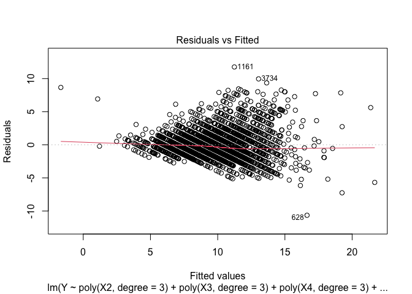

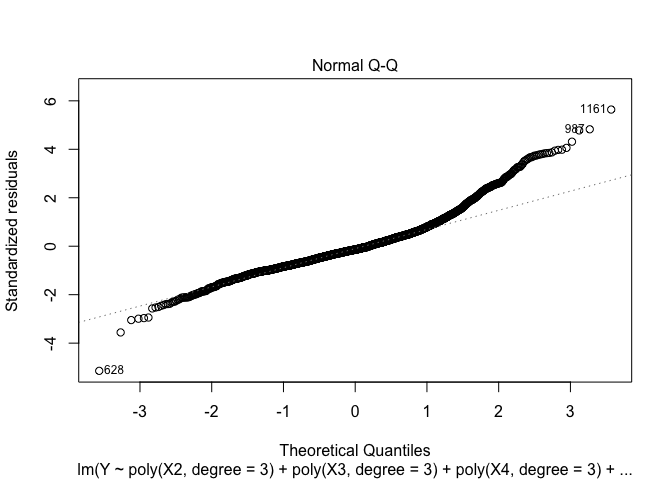

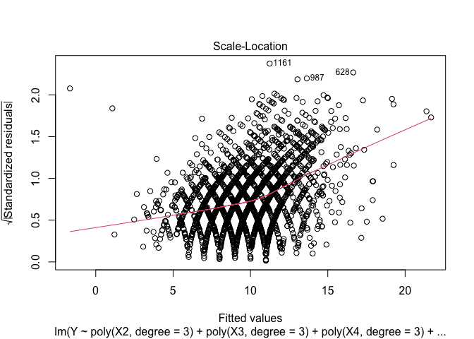

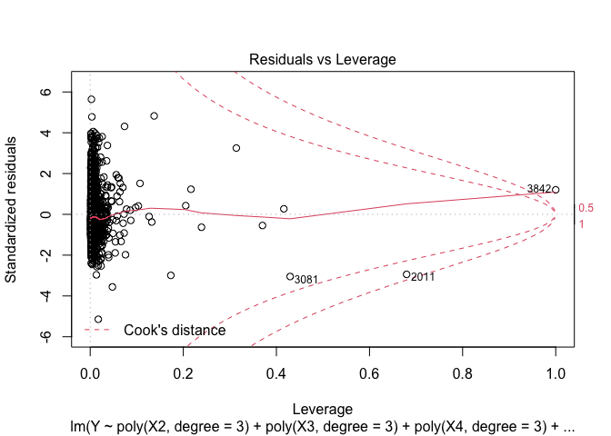

```r
plot(polynomial_model)
```

> We now have the linearity of the relationship between predictors and results. The residuals don’t look normally distributed. We don’t think that the homoscedasticity assumption is verified (cf. Scale-Location)

```r
polynomial_model_with_response_transformation <- lm(log(Y) ~ X1 + poly(X2, degree=3) + poly(X3, degree=3) + poly(X4, degree=3) + poly(X5, degree=3) + poly(X6, degree = 3) + poly(X7, degree = 3) + poly(X8, degree = 3, raw=T), data = training_set)
```

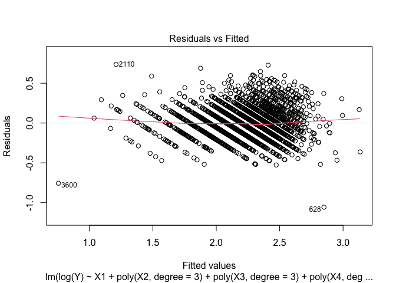

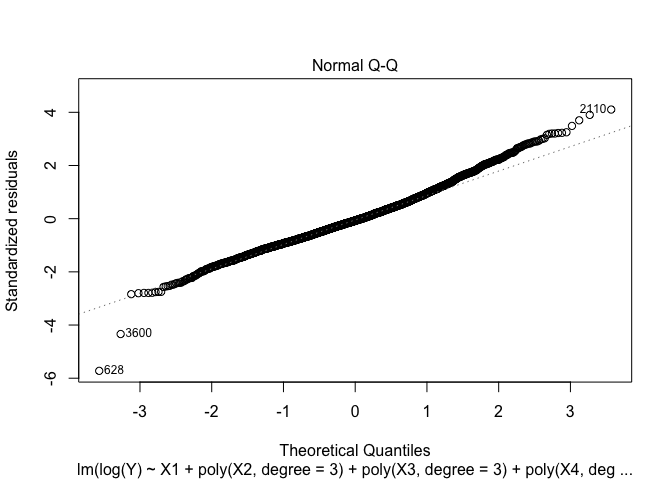

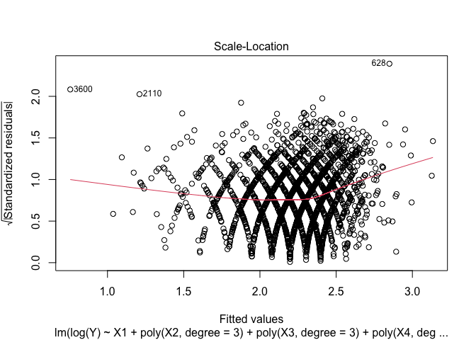

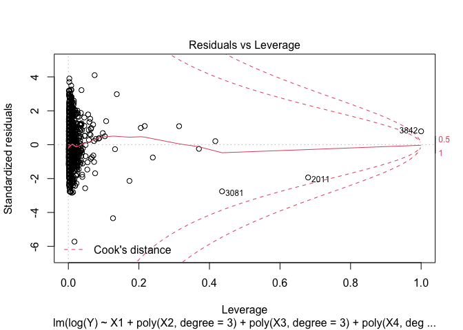

```r
plot(polynomial_model_with_response_transformation)
```

Again, try to pick the model with the best predictive performance

```r
predictions3 <- predict(polynomial_model, newdata = testing_set)
mean((predictions3 - testing_set$Y)^2)
```

```
## [1] 4.909567
```

```r
predictions4 <- predict(polynomial_model_with_response_transformation, newdata = testing_set)
mean((predictions4 - testing_set$Y)^2)
```

```
## [1] 70.6354
```